# Module 2 | Reporting with Quarto

Introduction to html quarto

Autor

Afiliação

A. Peralta-Santos

Escola Nacional de Saúde Pública

Data de Publicação

27 de dezembro de 2023

# 1 Título 1

Lorem ipsum dolor sit amet, consectetur adipiscing elit. Proin eu tempor velit. Fusce accumsan ultrices fringilla. Praesent sed odio mi. Mauris non ligula turpis. Duis posuere lacus nec diam interdum dictum suscipit magna molestie. Vestibulum nibh dolor, interdum eget rhoncus ut, sodales eget justo. Morbi blandit lorem sit amet nulla egestas aliquam. Nunc pharetra est at nibh ullamcorper in commodo erat dignissim. Cras et suscipit enim.

## 1.1 Título 2

Lorem ipsum dolor sit amet, consectetur adipiscing elit. Proin eu tempor velit. Fusce accumsan ultrices fringilla. Praesent sed odio mi. Mauris non ligula turpis. Duis posuere lacus nec diam interdum dictum suscipit magna molestie. Vestibulum nibh dolor, interdum eget rhoncus ut, sodales eget justo. Morbi blandit lorem sit amet nulla egestas aliquam. Nunc pharetra est at nibh ullamcorper in commodo erat dignissim. Cras et suscipit enim.

## 1.2 Título 2

Lorem ipsum dolor sit amet, consectetur adipiscing elit. Phasellus neque ex, vehicula dictum risus fermentum, feugiat faucibus neque. Etiam purus quam, lacinia vel porta in, malesuada ac nisl. Vestibulum ante ipsum primis in faucibus orci luctus et ultrices posuere cubilia curae; Sed bibendum placerat tellus, ac finibus lectus euismod eget. (Strabelli e Uip 2020)

### 1.2.1 Título 3

Este é o *quarto* curso de **R**

Nulla mattis diam vitae bibendum consequat. Etiam vitae eros tristique, porta sapien a, aliquet mauris. Praesent ultricies mi nulla, et dignissim nulla mattis at. Fusce rhoncus leo quis odio euismod, hendrerit facilisis risus tincidunt. Aenean at lectus justo. Cras fringilla lacus nisl, ac convallis odio tincidunt vel. Integer vel egestas nisi. Curabitur vitae imperdiet justo.

> Lorem ipsum dolor sit amet, consectetur adipiscing elit, sed do eiusmod tempor incididunt ut labore et dolore magna aliqua. Ut enim ad minim veniam, quis nostrud exercitation ullamco laboris nisi ut aliquip ex ea commodo consequat.

> penso logo existo - Descartes

## 1.3 Definir a configuração markdown

## 1.4 Criar um URL inline

Exemplo [aqui](https://www.statpower.net/Content/310/R%20Stuff/SampleMarkdown.html)

hiperlink publico

jornal expresso

hyperlink google

Novas ideias [Quarto website](https://quarto.org/docs/output-formats/html-basics.html)

Link para a localização do curso ENSP

## 1.5 Adicionar outra imagem

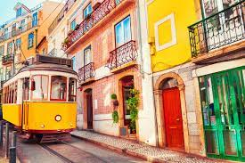

figure 1

[figure not shown]

Escola Nacional de Saúde Pública

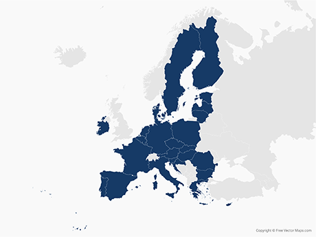

(a) European Map

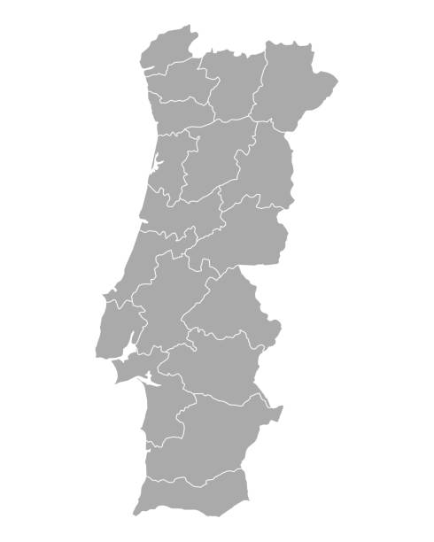

(b) Portugal

Figura 1: Mapas da Europa e Portugal

## 1.6 Referências

Veja Figura 1 para exemplos. Em particular, Figura 1 (b) ou Figura 1 (a)

## 1.7 Flowcharts

```
flowchart TD
  A[Population] --> B(Study population)

  B --> C{Salt substitute}

  C --> D[Exposed]

  C --> E[Not exposed]
```

```
flowchart TD
  A[Population] --> B(Study population)

  B --> C{Salt substitute}

  C --> D[Exposed]

  C --> E[Not exposed]
```

**ENSP**

Escola

**Data Science**

R

**Melhor edição**

Esta é que é a melhor

**Introdução**

Lorem ipsum dolor sit amet, consectetur adipiscing elit. Phasellus neque ex, vehicula dictum risus fermentum, feugiat faucibus neque. Etiam purus quam, lacinia vel porta in, malesuada ac nisl. Vestibulum ante ipsum primis in faucibus orci luctus et ultrices posuere cubilia curae

**Imagens**

[figure not shown]

Logotipo do curso

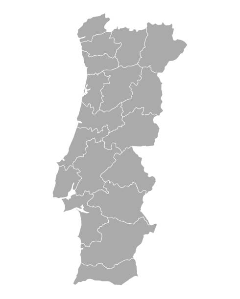

Portugal

## 1.8 Equações

Usar dois símbolos de dólar para uma equação separada do texto, e assim por diante.
$$E(log(Y_t))$$

$$E(log(Y_t)) = \beta_0 + \beta_{1-11} \sum_{m=1}^{m=12} MONTH_t + \beta_{12} TIME + \beta_{13} INT_t + \beta_{14} TIME*INT_t + log(POP_t) + \epsilon_t$$

equação simples $Y=ax+2$

usar um símbolo de dólar para equações inline no texto $E(log(Y_t))$

## 1.9 Código Inline e Code Annotations

```r
# O resultado de x será mostrado abaixo
a <- 2
b <- 2
x <- a+b
x
## [1] 4
```

**1**

Definir a,

**2**

Definir b,

**3**

Definir x como a soma de a mais b.

**4**

Mostrar x ao utilizador

O resultado de X é 4 dias.

O número total de doente é 20.

O número de B é 12.

O número de cirurgias desta semana é 70.

A média de idades e 43.

# 2 Formatação de Texto

## 2.1 Notas de Rodapé

Os estudantes de Data Science for healthcare são os melhores. [^1][^2]

Adoramos R! [^3]

Outra nota. [^4]

### 2.1.1 Criar um quadro

As quadros em quarto podem ser definidas de várias formas mas são divididas entre cabeçalho e conteúdo por um linebreak que é definido pelo caracter “-”. As colunas são separadas por “|” pelo menos no centro podendo ser omitidos na primeira e úttima posição. O RStudio por default assume logo a formatação pedida no formato visual.

Em que o default é “-” mas com as opções de alinhamento semelhantes aos processadores de texto: (este alinhamento é definido por coluna) - “:—-” Alinhamento à esquerda - “—-:” Alinhamento à direita - “:—-:” Alinhamento ao centro

| Tipo | Número | Estadia Média |
| --- | --- | --- |
| Hospitais | 5000 | 10 |
| Cuidados de Saúde Primários | 20000 | 1 |
| Cuidados de Longa Duração | 2000 | 100 |

A definição do espaçamento das colunas pode ser definido no Quarto em 3 posições:

1. No YMAL - com o parâmetro tbl-colwidths;
2. Em código que define a tabela; EX:Tabela “: Isto é um quadro {tbl-colwidths=”[75,15,10]“}”;
3. Pelo número relativo de caracteres de “-”.

Isto é um quadro

| Alunos | Nota | Total |
| --- | --- | --- |
| Liliana |  |  |

4.ª Edição

| dia | doentes |
| --- | --- |
| 8 | 150 |
| 2 | 160 |

#### 2.1.1.1 Inserir um URL

[this is a URL](https://www.ensp.unl.pt/cursos/cursos-de-curta-duracao/data-science-with-r-in-healthcare/)

Escrever em **negrito**

Escrever em *itálico*

#### 2.1.1.2 Inserir videos/conteúdo web

Como o Quarto funciona com suporte a múltiplas linguagens é possível colocar vários tipos de conteúdo.

Desde vídeos a iframe de HTMl permitindo embutir dentro do documento sites web.

[interactive chart not shown]

**Atenção**

A leitura em iframe é limitada no Firefox por segurança.

[video not shown]

#### 2.1.1.3 Criar listas

Sem ordem

- item 1
- item 2
- item 3

Com ordem

1. item 1
2. item 2
3. item 3

Vamos tentar fazer knitting a este markdown

- item 1
- item 2
1. primeiro
2. segundo

## 2.2 Criar Anotações

1. Notas “{.callout-note}”

**Nota**

Os dados estão atualizados até ao dia 2023-12-27

2. Avisos “{.callout-warning}”

**Aviso**

Não foi possível confirmar dados de 2023-12-27

3. Importante “{.callout-caution}”

**Cuidado**

Os dados estão atualizados até ao dia 2023-12-27

É possível melhorar a aparência destas anotações adicionando títulos:

“{.callout-note title=”Nota sobre dados”}”

**Nota sobre dados**

Os dados estão atualizados até ao dia 2023-12-27

Também é possível remover o ícone e tornar a nota menos proeminente.

“{.callout-note icon=false apperance=”mininal”}”

**Nota sobre dados**

Os dados estão atualizados até ao dia 2023-12-27

## 2.3 Criar referências

(SANTOS et al. 2022)

(Litaker, Koroukian, e Love 2005)

(Cowin, Rowlands, e Hatsell 2005)

(Sharma et al. 2010)

(Perkins-Kirkpatrick e Lewis 2020)

A COVID mata toda a gente com EAM. (Strabelli e Uip 2020)

## 2.4 Problemas

Instalar pandoc https://pandoc.org/installing.html

Para macbook M2 https://github.com/rstudio/rstudio/issues/12512

# 3 Referências

Cowin, Pamela, Tracey M Rowlands, e Sarah J Hatsell. 2005. «Cadherins and catenins in breast cancer». *Current opinion in cell biology* 17 (5): 499–508.

Litaker, David, Siran M Koroukian, e Thomas E Love. 2005. «Context and healthcare access: looking beyond the individual». *Medical care*, 531–40.

Perkins-Kirkpatrick, SE, e SC Lewis. 2020. «Increasing trends in regional heatwaves». *Nature communications* 11 (1): 3357.

SANTOS, ANDRE PERALTA, Pedro Pinto Leite, Pedro Casaca, Eugenia Fernandes, Eduardo Freire Rodrigues, Joana Moreno, Vasco Ricoca, et al. 2022. «Omicron (BA. 1) SARS-CoV-2 variant is associated with reduced risk of hospitalization and length of stay compared with Delta (B. 1.617. 2)». *medRxiv*.

Sharma, Ganesh N, Rahul Dave, Jyotsana Sanadya, Piush Sharma, KK3255438 Sharma, et al. 2010. «Various types and management of breast cancer: an overview». *Journal of advanced pharmaceutical technology & research* 1 (2): 109.

Strabelli, Tânia Mara Varejão, e David Everson Uip. 2020. «COVID-19 e o Coração». *Arquivos Brasileiros de Cardiologia*. SciELO Brasil.

## Notas de rodapé

[^1]: Isto é uma nota de rodapé.
[^2]: Readers Digest
[^3]: Isto é outra nota de rodapé
[^4]: outro teste